# NBA Raptor Metric Analysis

Author

Rashad Long

## Overview

The article chosen for this assignment was [**Introducing RAPTOR, Our New Metric For The Modern NBA**](https://fivethirtyeight.com/features/introducing-raptor-our-new-metric-for-the-modern-nba/)**.** RAPTOR stands for Robust Algorithm (using) Player Tracking (and) ON/Off Ratings. It is a plus-minus statistic that measures the number of points a player contributes to his team’s offense and defense per 100 possessions relative to a league average player. RAPTOR is based exclusively on publicly available data. The data sets used can be found here. NBA Raptor Datasets.

The dataset that I used is the latest_RAPTOR_by_player.csv. In this assignment I am only interested in the Raptor stats on offense and defense and minutes played by each player, so I created a new data frame with only those columns. I also changed the name of the mp column to minutes_played.

## Data Setup

Importing `dplyr` library and `ggplot2`

```r
library(dplyr)
library(ggplot2)
```

Reading the data from the csv file from Github.

```r
urlfile<-'https://raw.githubusercontent.com/RDLong718/DATA607-Spring24/main/DATA607-Spring2024/Assignments/nba-raptor/latest_RAPTOR_by_player.csv'
latest_Raptor_by_player<-read.csv(url(urlfile))
```

## Creating new data frame with only the columns needed

```r
nba_raptor <-
  latest_Raptor_by_player %>%
  select(player_name, raptor_offense, raptor_defense, raptor_total, mp)
```

Changing `mp` variable to `minutes_played`

```r
nba_raptor <- nba_raptor %>% rename(minutes_played = mp)
```

View new column names

```r
colnames(nba_raptor)
```

```
[1] "player_name"    "raptor_offense" "raptor_defense" "raptor_total"
[5] "minutes_played"
```

## Analysis

```r
nba_raptor %>%
  arrange(desc(raptor_offense)) %>%
  filter(minutes_played > 1000) %>%
  head(10)
```

```
         player_name raptor_offense raptor_defense raptor_total minutes_played
1       Nikola Jokic       9.522496      3.6962402    13.218736           3112
2     Damian Lillard       9.282637     -1.4661401     7.816497           2107
3        Luka Doncic       8.272470     -0.4488619     7.823608           2391
4      Stephen Curry       7.483712     -1.1653177     6.318394           2434
5  Tyrese Haliburton       6.902477     -0.9967542     5.905722           1883
6       Devin Booker       6.044340     -0.4081086     5.636231           2294
7   Donovan Mitchell       5.843209     -1.1340204     4.709188           2639
8      Jalen Brunson       5.733473     -0.9604858     4.772987           2822
9       Kyrie Irving       5.614030      0.3538353     5.967865           2241
10      Jimmy Butler       5.529827      0.6870509     6.216878           3012
```

The relationship between the Raptor offense and defense metrics is shown in the scatter plot below. The plot shows that there is a positive correlation between the two metrics.

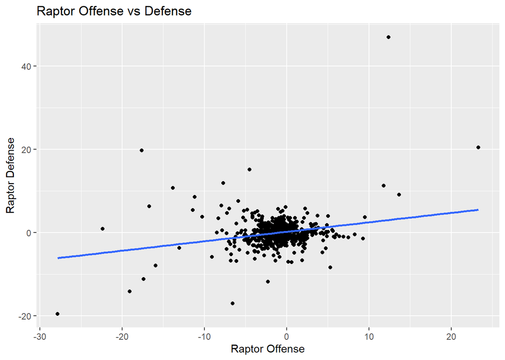

```r
ggplot(nba_raptor, aes(x = raptor_offense, y = raptor_defense)) +
  geom_point() +
  geom_smooth(method = "lm", formula = y ~ x, se = FALSE) +
  labs(title = "Raptor Offense vs Defense",
       x = "Raptor Offense",
       y = "Raptor Defense")
```

## Conclusion

I found it interesting in how the Raptor Metric works. [Methodological Explainer](https://fivethirtyeight.com/features/how-our-raptor-metric-works/). I would love to analyze the relationship between the Raptor Metric and other modern NBA metrics used. This would require reading in additional datasets and merging them together.

One thing I would update is some of the names of the variables. For instance the `mp` variable should be changed to `minutes_played`. The `poss` variable should be changed to `possessions`. This would make the data more readable and easier to understand.